# Chapter 08: Exponential smoothing

maurogm 2023-08-15

- Link
- Simple exponential smoothing
- Methods with trend
  - Holt’s linear trend method
  - Damped trend methods
  - Example: Internet usage
- Methods with seasonality (Holt-Winters)
  - Example: Holt-Winters method with daily data
- Estimation and model selection

## Link

https://otexts.com/fpp3/expsmooth.html

## Simple exponential smoothing

Es el promedio exponencial simple, donde cada observación tiene un peso alpha y el forecast anterior tiene un peso 1 - alpha. En la formulación que hace, en vez de asignar a la primera observación un peso igual a 1, considera el forecast para t=0 como un hiperparametro a setear, al igual que alpha.

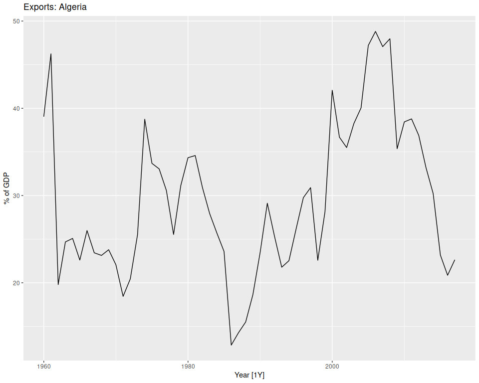

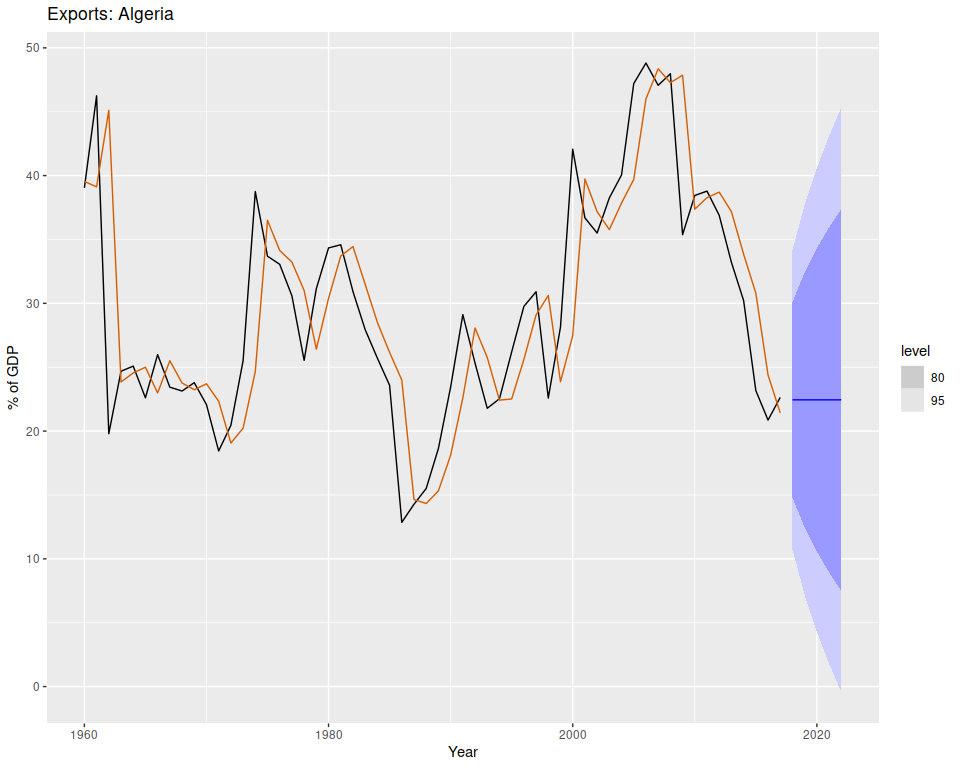

```r
algeria_economy <- global_economy %>%
  filter(Country == "Algeria")
algeria_economy %>%
  autoplot(Exports) +
  labs(y = "% of GDP", title = "Exports: Algeria")

# Estimate parameters
fit <- algeria_economy %>%
  model(ETS(Exports ~ error("A") + trend("N") + season("N")))
fc <- fit %>%
  forecast(h = 5)

fc %>%
  autoplot(algeria_economy) +
  geom_line(aes(y = .fitted),
    col = "#D55E00",
    data = augment(fit)
  ) +
  labs(y = "% of GDP", title = "Exports: Algeria") +
  guides(colour = "none")
```

## Methods with trend

### Holt’s linear trend method

Acá en vez de tener un único componente igual al nivel de la serie, se le agrega al forecast una componente de tendencia. Ambas componentes se van actualizando con un promedio exponencial, cada una con su propio decaimiento.

Veamos un ejemplo con una serie de crecimiento poblacional:

```
## Series: Pop
## Model: ETS(A,A,N)
##   Smoothing parameters:
##     alpha = 0.9999
##     beta  = 0.3266366
##
##   Initial states:
##      l[0]      b[0]
##  10.05414 0.2224818
##
##   sigma^2:  0.0041
##
##       AIC      AICc       BIC
## -76.98569 -75.83184 -66.68347
```

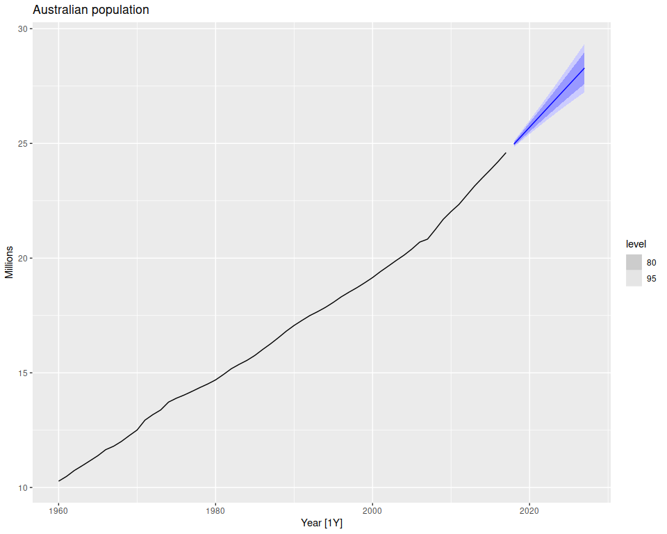

```r
aus_economy <- global_economy %>%
  filter(Code == "AUS") %>%
  mutate(Pop = Population / 1e6)

fit <- aus_economy %>%
  model(
    AAN = ETS(Pop ~ error("A") + trend("A") + season("N"))
  )
fc <- fit %>% forecast(h = 10)

autoplot(aus_economy, Pop) +
  autolayer(fc) +
  labs(y = "Millions", title = "Australian population")

fit %>% report()
```

Vemos que alpha es casi 1, lo que indica que el forecast es prácticaente la observación anterior más la tendencia. El beta también es elevado, lo que indica que la misma se actualiza bastante rápido (lo que tiene sentido dada la aceleración del crecimiento poblacional).

### Damped trend methods

Dado que el método de Holt haría que el forecast siga creciendo/decreciendo indefinidamente, se le agrega un factor de amortiguamiento phi para que en el horizonte el forecast se estabilice en una constante. Por cada paso que se adelanta en el horizonte, el factor de amortiguamiento que multiplica a la tendencia se eleva a la potencia del número de pasos.

El phi suele estar entre 0.8 (menos hace que la tendencia muera demasiado rápido) y 0.98 (más hace que la tendencia muera muy lentamente).

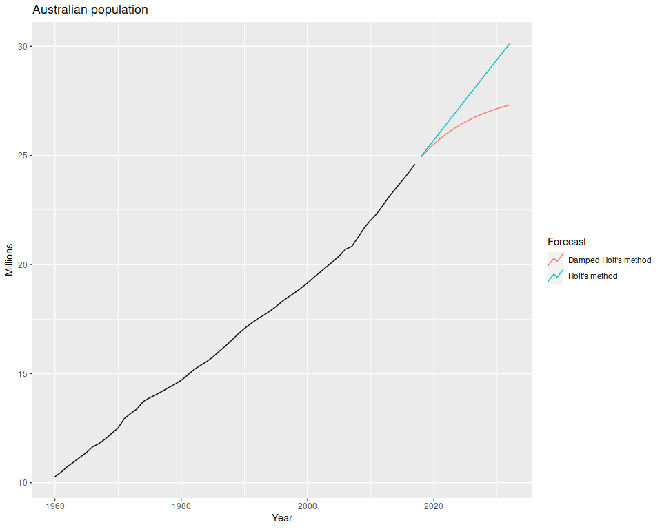

```r
aus_economy %>%
  model(
    `Holt's method` = ETS(Pop ~ error("A") +
      trend("A") + season("N")),
    `Damped Holt's method` = ETS(Pop ~ error("A") +
      trend("Ad", phi = 0.9) + season("N"))
  ) %>%
  forecast(h = 15) %>%
  autoplot(aus_economy, level = NULL) +
  labs(
    title = "Australian population",
    y = "Millions"
  ) +
  guides(colour = guide_legend(title = "Forecast"))
```

Acá se seteó phi = 0.9, pero se puede estimar junto al resto de lo parámetros.

### Example: Internet usage

Se tiene una serie con la cantidad de usuarios conectados a un server minuto a minuto.

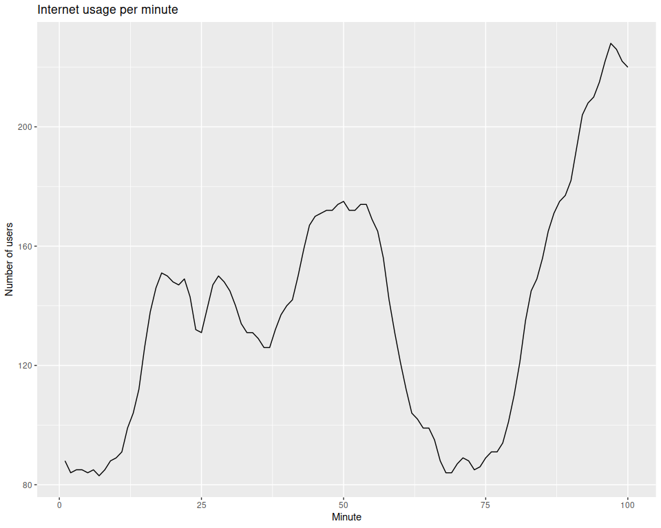

```r
www_usage <- as_tsibble(WWWusage)
www_usage %>% autoplot(value) +
  labs(
    x = "Minute", y = "Number of users",
    title = "Internet usage per minute"
  )
```

Probamos los 3 métodos vistos hasta ahora, y vemos cuál se ajusta mejor usando cross-validation:

```r
www_usage %>%
  stretch_tsibble(.init = 10) %>%
  model(
    SES = ETS(value ~ error("A") + trend("N") + season("N")),
    Holt = ETS(value ~ error("A") + trend("A") + season("N")),
    Damped = ETS(value ~ error("A") + trend("Ad") +
      season("N"))
  ) %>%
  forecast(h = 1) %>%
  accuracy(www_usage)
```

```
## # A tibble: 3 × 10
##   .model .type     ME  RMSE   MAE   MPE  MAPE  MASE RMSSE  ACF1
##   <chr>  <chr>  <dbl> <dbl> <dbl> <dbl> <dbl> <dbl> <dbl> <dbl>
## 1 Damped Test  0.288   3.69  3.00 0.347  2.26 0.663 0.636 0.336
## 2 Holt   Test  0.0610  3.87  3.17 0.244  2.38 0.701 0.668 0.296
## 3 SES    Test  1.46    6.05  4.81 0.904  3.55 1.06  1.04  0.803
```

Damped Holt es el mejor, así que lo usamos para forecastear 10 minutos más:

```r
fit <- www_usage %>%
  model(
    Damped = ETS(value ~ error("A") + trend("Ad") +
      season("N"))
  )
```

Estimated parameters:

```r
tidy(fit)
```

```
## # A tibble: 5 × 3
##   .model term  estimate
##   <chr>  <chr>    <dbl>
## 1 Damped alpha   1.00
## 2 Damped beta    0.997
## 3 Damped phi     0.815
## 4 Damped l[0]   90.4
## 5 Damped b[0]   -0.0173
```

Vemos que debido a los saltos en la serie histórica, nuestros intervalos de confianza son bastante amplios:

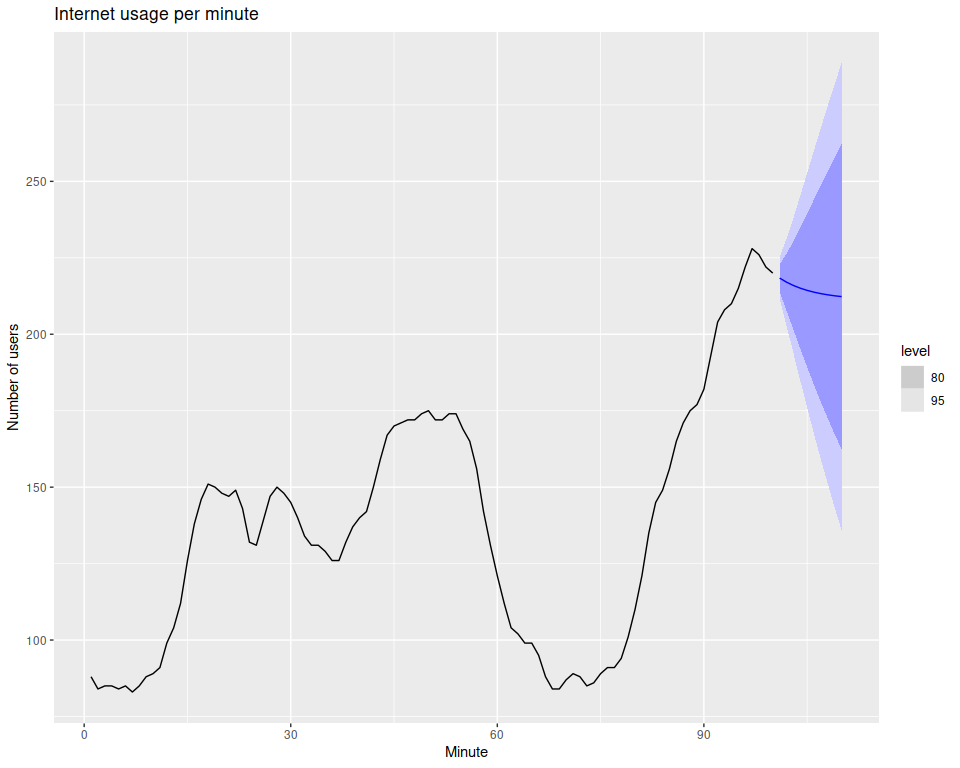

```r
fit %>%
  forecast(h = 10) %>%
  autoplot(www_usage) +
  labs(
    x = "Minute", y = "Number of users",
    title = "Internet usage per minute"
  )
```

## Methods with seasonality (Holt-Winters)

Podemos considerar que la componente estacional es tanto aditiva como multiplicativa.

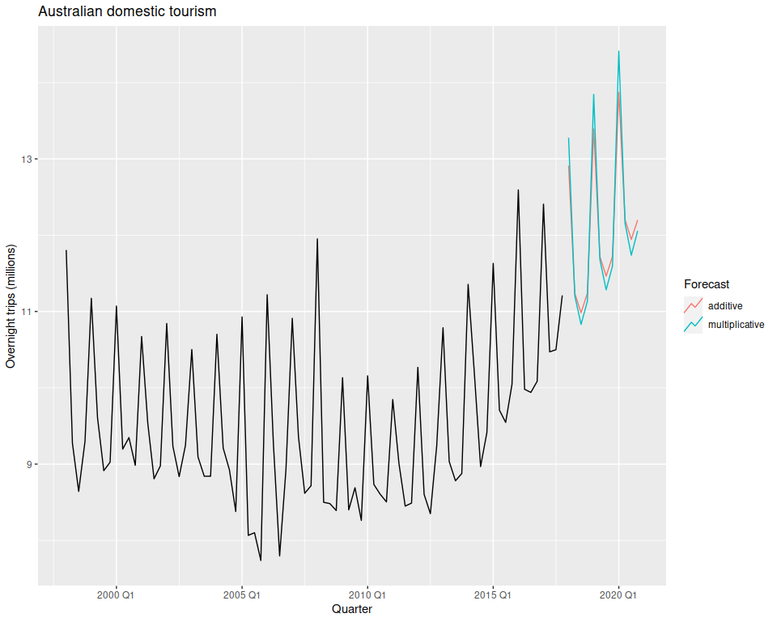

```r
aus_holidays <- tourism |>
  filter(Purpose == "Holiday") |>
  summarise(Trips = sum(Trips) / 1e3)
fit <- aus_holidays |>
  model(
    additive =
      ETS(Trips ~ error("A") + trend("A") + season("A")),
    multiplicative =
      ETS(Trips ~ error("M") + trend("A") + season("M"))
  )
fc <- fit |> forecast(h = "3 years")
fc |>
  autoplot(aus_holidays, level = NULL) +
  labs(
    title = "Australian domestic tourism",
    y = "Overnight trips (millions)"
  ) +
  guides(colour = guide_legend(title = "Forecast"))
```

### Example: Holt-Winters method with daily data

A continuación un ejemplo usando el Holt-Winters’ damped multiplicative method. Se dice que este esquema (ETS(M,Ad,M)) es de los más usados en la práctica.

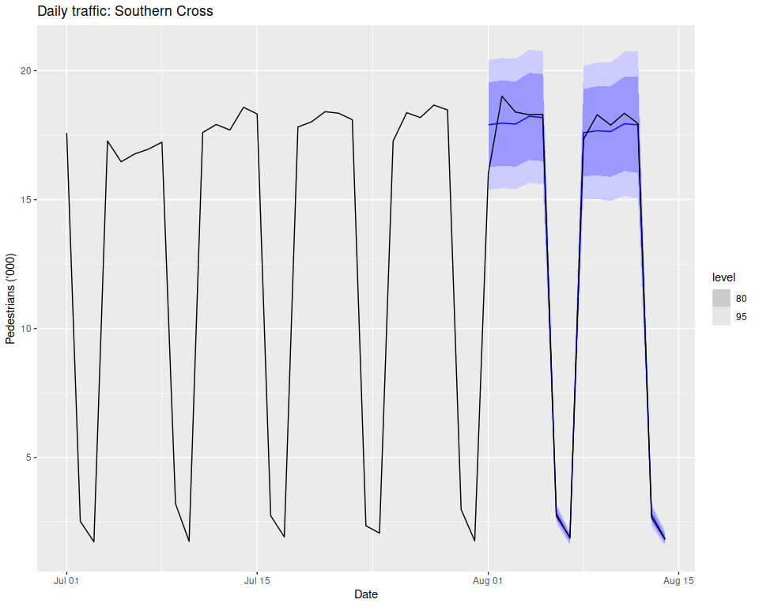

```r
sth_cross_ped <- pedestrian |>
  filter(
    Date >= "2016-07-01",
    Sensor == "Southern Cross Station"
  ) |>
  index_by(Date) |>
  summarise(Count = sum(Count) / 1000)

sth_cross_ped |>
  filter(Date <= "2016-07-31") |>
  model(
    hw = ETS(Count ~ error("M") + trend("Ad") + season("M"))
  ) |>
  forecast(h = "2 weeks") |>
  autoplot(sth_cross_ped |> filter(Date <= "2016-08-14")) +
  labs(
    title = "Daily traffic: Southern Cross",
    y = "Pedestrians ('000)"
  )
```

## Estimation and model selection

La función ETS, si no se le pasa ningún parámetro, estima por sí sola el mejor modelo en función de la métrica AICc:

```r
aus_holidays <- tourism |>
  filter(Purpose == "Holiday") |>
  summarise(Trips = sum(Trips) / 1e3)

fit <- aus_holidays |>
  model(ETS(Trips))
```

Podemos ver que el modelo elegido es un ETS(M,N,A), junto a los parámetros estimados:

```r
report(fit)
```

```
## Series: Trips
## Model: ETS(M,N,A)
##   Smoothing parameters:
##     alpha = 0.3484054
##     gamma = 0.0001000018
##
##   Initial states:
##      l[0]       s[0]      s[-1]      s[-2]    s[-3]
##  9.727072 -0.5376106 -0.6884343 -0.2933663 1.519411
##
##   sigma^2:  0.0022
##
##      AIC     AICc      BIC
## 226.2289 227.7845 242.9031
```

Si deseamos, podemos graficar los componentes del modelo:

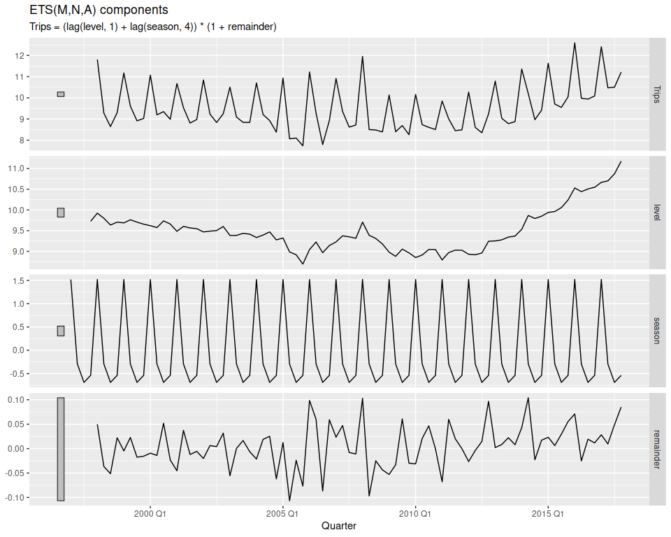

```r
components(fit) |>
  autoplot() +
  labs(title = "ETS(M,N,A) components")
```